# Greenhouse gas benefit from protection against Hemlock Looper

### British Columbia's Forest Carbon Initiative

Robbie A Hember, PhD, P.Ag.

Last updated: 2020-12-09

Climate Change and Integrated Planning Branch,  
Office of the Chief Forester,  
Forests Lands, Natural Resource Operations and Rural Development  
Government of British Columbia  
545 Superior Street, Victoria, Canada  
robert.hember@gov.bc.ca

## Introduction

This project analyzes the hemlock looper.

## Methods

### Prepare session

First let's prepare the session in Jupyter Notebooks and import the required python packages. To do this work, we will use the model *cbrunner* from the *fcgadgets* repository. Set how graphic display parameters.

Import graphics parameters for FCI demos using the funciton, *fcgadgets.cbrunner.cbrun_Utilities.Import_GraphicsParameters*.

### Prepare inputs

Start to configure the project based on project parameters and scenario parameters in ProjectConfig.xlsx. Set the directory path to the project data.

Specify scenarios:

### Run the simulation and import results

```
Running Scenario 0001, Ensemble(s) 1 through 1, Batch 0001
1.5095562934875488
Running Scenario 0002, Ensemble(s) 1 through 1, Batch 0001
1.4480953216552734
Running Scenario 0003, Ensemble(s) 1 through 1, Batch 0001
1.4183986186981201
Running Scenario 0004, Ensemble(s) 1 through 1, Batch 0001
1.4273617267608643
```

### Plot results

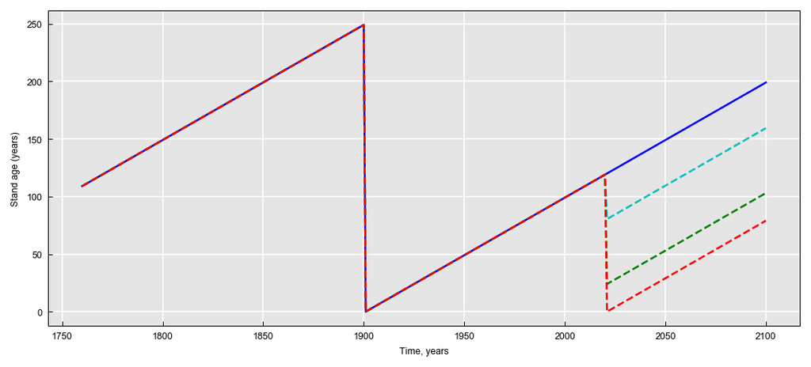

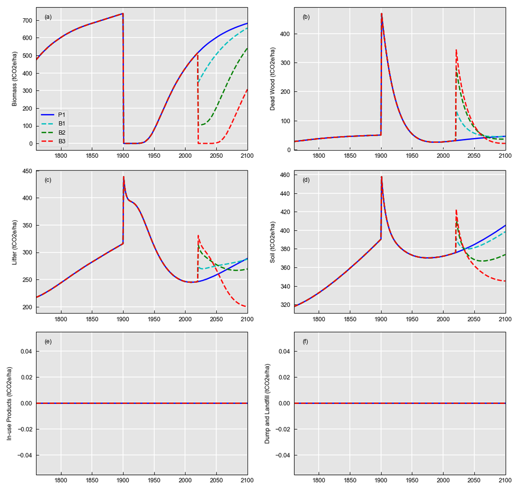

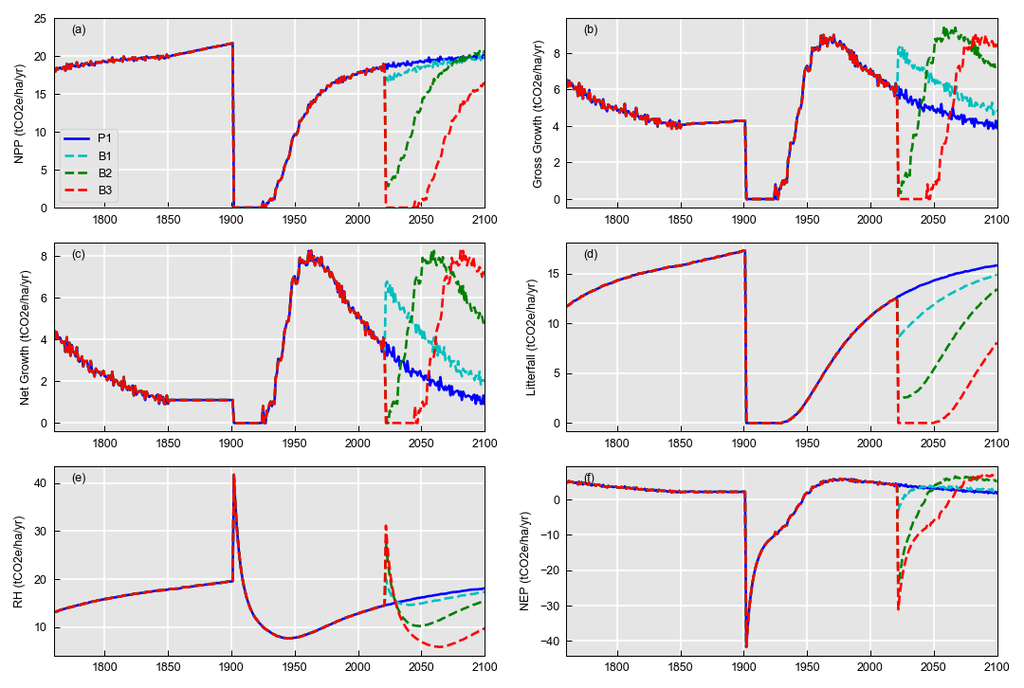